# Transcriptome and genome sequencing uncovers functional variation in humans Data Visualization Group Project

**Transcriptome and genome sequencing uncovers functional variation in humans**  
Data Visualization Group Project

[figure not shown]

Eira Fontanals Muñoz 2025-03-19

## Description of the Data Set

### Source and Purpose

The dataset is from *Lappalainen et al., Nature 2013* and contains expression quantitative trait loci (eQTL) associations. It includes associations between genetic variants (SNPs) and gene expression traits, collected for the purpose of studying genetic regulation of gene expression. The dataset focuses on variants meeting a **False Discovery Rate (FDR) threshold of 5%** or the best association for each gene/unit.

### Variables and Meanings

| Column | Variable Name | Description | Unit |
| --- | --- | --- | --- |
| 1 | **SNP_ID** | Variant identifier (from dbSNP 137) | - |
| 2 | **ID** | Always Null (-) | - |
| 3 | **GENE_ID** | Gene identifier (Gencode v12) | - |
| 4 | **PROBE_ID** | Quantitative trait identifier | - |
| 5 | **CHR_SNP** | Chromosome of the variant | - |
| 6 | **CHR_GENE** | Chromosome of the quantitative trait | - |
| 7 | **SNPpos** | Position of the variant | Base pairs |
| 8 | **TSSpos** | Transcription start site of the gene | Base pairs |
| 9 | **Distance** | Absolute distance between SNPpos and TSSpos | Base pairs |
| 10 | **rvalue** | Spearman rank correlation (direction of effect) | - |
| 11 | **pvalue** | Association p-value | - |
| 12 | **log10pvalue** | -log10 transformed p-value | - |

### Long Format Check

The dataset is in a **wide format** where each row represents a single SNP-gene association. However, depending on the analysis, it may need to be reshaped into a long format.

## Read the Dataset

```r
data <- read.table("dataset.txt", header = FALSE, sep = "\t", stringsAsFactors = FALSE)
colnames(data) <- c("SNP_ID", "ID", "GENE_ID", "PROBE_ID", "CHR_SNP", "CHR_GENE", "SNPpos", "TSSpos", "Distance", "rvalue", "pvalue", "log10pvalue")
```

## Reshape Data (if necessary)

The dataset is currently in a structured format where each row represents an SNP-gene association. However, the ID column contains only hyphens (“-”), which provides no meaningful information. Therefore, it is advisable to remove this column to maintain a clean dataset.

Additionally, reshaping the data into a long format may be necessary for certain analyses, such as:

- If we want to plot multiple metrics (rvalue, pvalue, log10pvalue) together.
- If we need to group, summarize, or perform statistical analyses across different metrics.

```r
# Remove 'ID' column
data <- subset(data, select = -ID)
# Reshaping the dataset
data_long <- data %>% pivot_longer(cols = c("rvalue", "pvalue", "log10pvalue"), names_to = "Metric", values_to = "Value")
head(data_long)
```

```
## # A tibble: 6 × 10
##   SNP_ID         GENE_ID PROBE_ID CHR_SNP CHR_GENE SNPpos TSSpos Distance Metric
##   <chr>          <chr>   <chr>      <int>    <int>  <dbl>  <int>    <dbl> <chr>
## 1 snp_20_305339… ENSG00… ENSG000…      20       20 3.05e7 3.05e7    75444 rvalue
## 2 snp_20_305339… ENSG00… ENSG000…      20       20 3.05e7 3.05e7    75444 pvalue
## 3 snp_20_305339… ENSG00… ENSG000…      20       20 3.05e7 3.05e7    75444 log10…
## 4 rs1985842      ENSG00… ENSG000…      22       22 4.25e7 4.25e7    56563 rvalue
## 5 rs1985842      ENSG00… ENSG000…      22       22 4.25e7 4.25e7    56563 pvalue
## 6 rs1985842      ENSG00… ENSG000…      22       22 4.25e7 4.25e7    56563 log10…
## # ℹ 1 more variable: Value <dbl>
```

Reshaping the data may be usefull in the scenarios we have specified, even thought, our data can be perfectly analysed using the wide format because we will use only one metric (log10pvalue).

## Check and Update Variable Classes

```r
str(data)
```

```
## 'data.frame':    3259 obs. of  11 variables:
##  $ SNP_ID     : chr  "snp_20_30533949" "rs1985842" "rs2272804" "rs115848216" ...
##  $ GENE_ID    : chr  "ENSG00000131044.11" "ENSG00000198951.6" "ENSG00000128408.7" "ENSG00000011052.16" ...
##  $ PROBE_ID   : chr  "ENSG00000131044.11" "ENSG00000198951.6" "ENSG00000128408.7" "ENSG00000011052.16" ...
##  $ CHR_SNP    : int  20 22 22 17 1 19 2 1 12 16 ...
##  $ CHR_GENE   : int  20 22 22 17 1 19 2 1 12 16 ...
##  $ SNPpos     : num  30533949 42523409 45809624 49243859 16061035 ...
##  $ TSSpos     : int  30458505 42466846 45809572 49230951 16062900 57078890 233415226 201857808 124457378 56554195 ...
##  $ Distance   : num  75444 56563 52 12908 1865 ...
##  $ rvalue     : num  -0.416 0.299 -0.598 -0.281 -0.353 ...
##  $ pvalue     : num  4.63e-17 3.74e-09 1.80e-37 3.39e-08 2.17e-12 ...
##  $ log10pvalue: num  16.33 8.43 36.74 7.47 11.66 ...
```

All variables were correctly read, except that SNPpos and Distance were initially detected as numeric instead of integers. Also the chromosomes should be expressed by factors (categorical) explicitly convert them to integers to ensure consistency.

```r
data <- data %>%
  mutate(
    SNPpos = as.integer(SNPpos),
    Distance = as.integer(Distance),
    CHR_SNP = as.factor(CHR_SNP),
    CHR_GENE = as.factor(CHR_GENE)
  )

# Checking the updated structure
str(data)
```

```
## 'data.frame':    3259 obs. of  11 variables:
##  $ SNP_ID     : chr  "snp_20_30533949" "rs1985842" "rs2272804" "rs115848216" ...
##  $ GENE_ID    : chr  "ENSG00000131044.11" "ENSG00000198951.6" "ENSG00000128408.7" "ENSG00000011052.16" ...
##  $ PROBE_ID   : chr  "ENSG00000131044.11" "ENSG00000198951.6" "ENSG00000128408.7" "ENSG00000011052.16" ...
##  $ CHR_SNP    : Factor w/ 22 levels "1","2","3","4",..: 20 22 22 17 1 19 2 1 12 16 ...
##  $ CHR_GENE   : Factor w/ 22 levels "1","2","3","4",..: 20 22 22 17 1 19 2 1 12 16 ...
##  $ SNPpos     : int  30533949 42523409 45809624 49243859 16061035 57063916 233410922 201847842 124494528 56506126 ...
##  $ TSSpos     : int  30458505 42466846 45809572 49230951 16062900 57078890 233415226 201857808 124457378 56554195 ...
##  $ Distance   : int  75444 56563 52 12908 1865 14974 4304 9966 37150 48069 ...
##  $ rvalue     : num  -0.416 0.299 -0.598 -0.281 -0.353 ...
##  $ pvalue     : num  4.63e-17 3.74e-09 1.80e-37 3.39e-08 2.17e-12 ...
##  $ log10pvalue: num  16.33 8.43 36.74 7.47 11.66 ...
```

## Explore Data with ggplot2

### Distribution of Variables

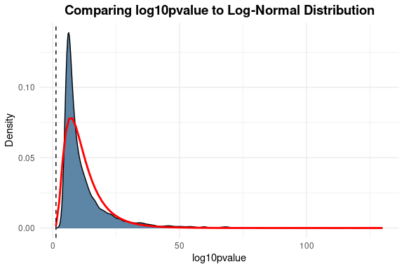

```r
# Histogram of a continuous variable (log10pvalue)
fit <- fitdistr(data$log10pvalue, "lognormal")
ggplot(data, aes(x = log10pvalue)) +
  geom_density(fill = "#4b789c", alpha = 0.9) +
  stat_function(fun = dlnorm, args = list(meanlog = fit$estimate[1], sdlog = fit$estimate[2]), color = "red", linewidth = 1) +
  geom_vline(xintercept = -log10(0.05), linetype = "dashed", color = "black") +
  theme_minimal() +
  labs(title = "Comparing log10pvalue to Log-Normal Distribution", x = "log10pvalue", y = "Density")+
  theme(legend.position ='none', plot.title = element_text(hjust = 0.5, face = "bold", size = 14))
```

**Interpretation:** The density plot of log10pvalue compared to a log-normal distribution shows that all observed values are greater than the threshold indicated by the black dashed line. This suggests that the detected eQTL associations are statistically significant, as there are no values falling below this threshold. The blue density curve represents the empirical distribution, while the red curve corresponds to the fitted log-normal model. The observed right-skewed distribution indicates that while most eQTLs have moderate significance levels, a subset exhibits highly significant associations (large log10pvalues). The long tail further highlights the presence of exceptionally strong regulatory variants, which could be key players in gene expression regulation. This pattern is expected in eQTL studies, where only a fraction of genetic variants exert strong effects on transcriptional activity.

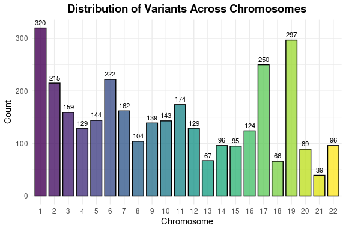

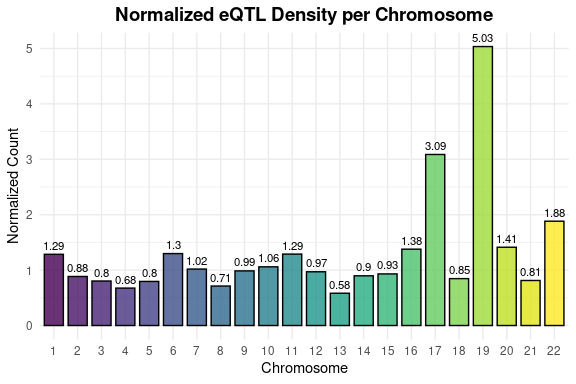

```r
# Bar plot of a discrete variable (CHR_SNP)
ggplot(data, aes(x = CHR_SNP, fill=CHR_SNP)) +
  geom_bar(alpha = 0.8, color = "black", width = 0.8) +
  geom_text(stat = "count", aes(label = after_stat(count)), vjust = -0.5, size=3) +
  labs(title = "Distribution of Variants Across Chromosomes", x = "Chromosome", y = "Count") +
  scale_fill_viridis_d()+
  theme_minimal()+
  theme(legend.position ='none', plot.title = element_text(hjust = 0.5, face = "bold", size = 14))

# Graph 2. Bar plot of a discrete variable (CHR_SNP) Normalized
# Define chromosome lengths as a lookup table
chr_lengths <- data.frame(
  CHR_SNP = as.factor(1:22),
  chr_length = c(249, 243, 198, 191, 181, 171, 159, 146, 141, 135,
                 135, 133, 115, 107, 102, 90, 81, 78, 59, 63, 48, 51)
)

# Merge the chromosome length data into the main dataset
data <- left_join(data, chr_lengths, by = "CHR_SNP")

# Compute the normalized count per chromosome
data_summary <- data %>%
  group_by(CHR_SNP) %>%
  summarise(normalized_count = n() / unique(chr_length))

# Plot the normalized eQTL density
ggplot(data_summary, aes(x = CHR_SNP, y = normalized_count, fill = CHR_SNP)) +
  geom_bar(stat = "identity", alpha = 0.8, color = "black", width = 0.8) +
  geom_text(aes(label = round(normalized_count, 2)), vjust = -0.5, size=3) +
  scale_fill_viridis_d() +
  theme_minimal()+
  labs(title = "Normalized eQTL Density per Chromosome", x = "Chromosome", y = "Normalized Count") +
  theme(legend.position ='none', plot.title = element_text(hjust = 0.5, face = "bold", size = 14))
```

Graph 1 shows that Chromosome 1 has the highest number of eQTL associations. This can be due to chromosome 1 is the largest human chromosome, containing the highest number of genes (~2,000 genes). More genes directly implies more potential regulatory variants. Some key regulatory regions might be enriched on Chromosome 1, leading to more detected eQTLs. The analysis of normalized eQTL density per chromosome (Graph 2) reveals significant variability in the distribution of regulatory variants across the genome. While most chromosomes exhibit a relatively uniform eQTL density, Chromosome 19 and Chromosome 17 stand out with disproportionately high densities, suggesting the presence of key regulatory hotspots or higher transcriptional activity in these regions. Conversely, chromosomes such as 4 and 13 display notably lower densities, which may be attributed to lower gene content, fewer functional regulatory elements, or dataset biases. These findings highlight potential areas of genomic regulation that warrant further investigation, particularly in relation to gene density, chromatin accessibility, and evolutionary constraints. It is also important to note that before normalization, Chromosome 1 had the highest absolute count of eQTLs. While this is partially due to its large size, it also suggests that Chromosome 1 plays a crucial role in transcriptional regulation, possibly due to its gene density and regulatory complexity. This reinforces the need to consider both absolute and normalized values when interpreting the results.

### Summarizing Data

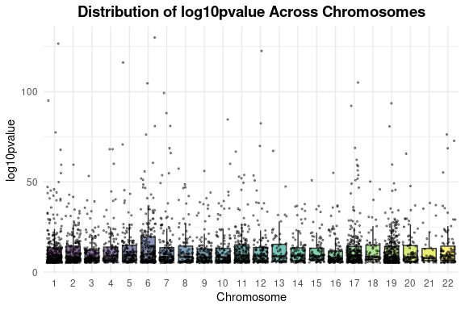

```r
#Boxplot of log10pvalues across chromosomes
ggplot(data, aes(x = factor(CHR_SNP), y = log10pvalue, fill = factor(CHR_SNP))) +
  geom_boxplot(alpha = 0.6, outlier.shape = NA) +
  geom_jitter(color = "black", size = 0.5, alpha = 0.4) +
  scale_fill_viridis_d() +
  labs(title = "Distribution of log10pvalue Across Chromosomes",
       x = "Chromosome",
       y = "log10pvalue") +
  theme_minimal() +
  theme(legend.position ='none', plot.title = element_text(hjust = 0.5, face = "bold", size = 14))
```

The boxplot displaying the distribution of log10pvalues across chromosomes reveals that while most values are concentrated at lower ranges, there are a considerable number of outliers, indicating highly significant eQTLs on certain chromosomes. Notably, some chromosomes, such as 6 and 19, exhibit a wider spread of log10pvalues, suggesting they harbor more significant eQTLs. However, due to overlapping distributions and the presence of numerous outliers, it is difficult to discern specific trends or patterns across chromosomes. A more refined visualization, such as a violin plot or a Manhattan plot, could help improve the clarity of these findings.

### Selecting the Best Graphs

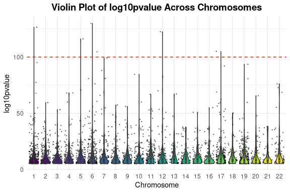

```r
#Violin plot of log10pvalues across chromosomes
ggplot(data, aes(x = as.factor(CHR_SNP), y = log10pvalue, fill = as.factor(CHR_SNP))) +
  geom_jitter(color = "black", size = 0.3, alpha = 0.4) +
  geom_violin() +
  geom_boxplot(width = 0.1, outlier.shape = NA, alpha = 0.6) +
  geom_hline(yintercept = 100, linetype = "dashed", color = "red") + # Variants exceeding this threshold are considered extremely strong candidates for functional regulatory elements.
  scale_fill_viridis_d() +
  labs(title = "Violin Plot of log10pvalue Across Chromosomes",
       x = "Chromosome",
       y = "log10pvalue") +
  theme_minimal() +
  theme(legend.position = "none")+
  theme(plot.title = element_text(hjust = 0.5, face = "bold", size = 14))
```

The violin plot allows us to pinpoint chromosomes harboring the most highly significant eQTLs, particularly those exceeding the log10pvalue threshold of 100. Chromosomes 1, 5, 6, 12, and 17 emerge as key regions containing exceptionally strong regulatory variants. This does not diminish the relevance of other chromosomes but instead focuses on those with the most extreme values. Additionally, the density of these highly significant eQTLs varies across chromosomes, indicating that different regions may contribute differently to transcriptional regulation. To further investigate which specific variants are driving these signals, a Manhattan plot could be used to visualize their genomic locations and significance levels, providing a more detailed view of eQTL distribution across the genome.

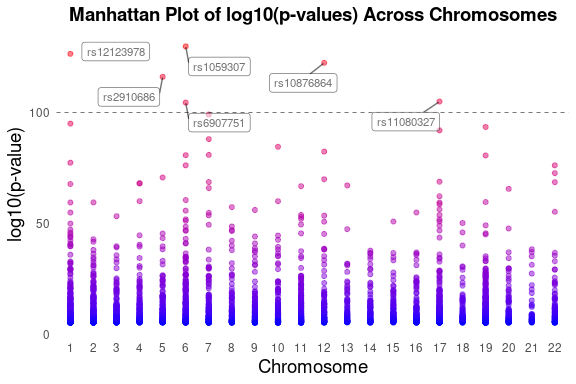

```r
#Manhattan plot of log10pvalues across chromosomes

# Define significance threshold
threshold <- 100

# Create a subset of the data for SNPs with log10pvalue > threshold
highlight_snps <- data[data$log10pvalue > threshold, ]

# Manhattan Plot
manhattan_plot <- ggplot(data, aes(x = CHR_SNP, y = log10pvalue)) +
  geom_point(aes(color = log10pvalue), alpha = 0.5, size = 1.5) +
  scale_color_gradient(low = "blue", high = "red")+
  labs(title = "Manhattan Plot of log10(p-values) Across Chromosomes",
       x = "Chromosome", y = "log10(p-value)") +
  theme_minimal() +
  geom_hline(yintercept = threshold, color = "black", linetype = "dashed", linewidth = 0.2) +
  geom_label_repel(data = highlight_snps,
                   aes(label = SNP_ID, alpha=0.7),
                   size = 3, color = "black",
                   force = 1.7,
                   box.padding = 0.5) +
  theme(plot.title = element_text(hjust = 0.5, face = "bold", size = 14),
        axis.title = element_text(size = 14),
        legend.position = "none",
        panel.grid.major = element_blank(),
        panel.grid.minor = element_blank())

manhattan_plot
```

To further investigate which specific variants are driving these signals, we use the Manhattan plot, which provides a clearer view of individual SNPs with the highest significance. As seen in the plot, variants such as rs12123978, rs2910686, rs1059307, rs6907751, rs10876864, and rs11080327 stand out as key eQTLs surpassing the threshold. These SNPs may represent important regulatory elements influencing gene expression. Further functional analysis of these variants could provide valuable insights into their biological roles in transcriptional regulation.

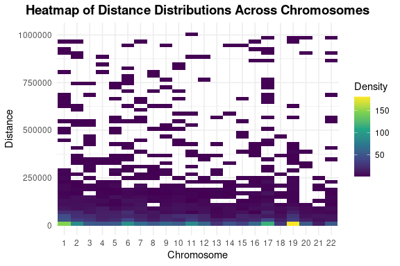

```r
#Heat map plot of distance across chromosomes
heatmap_plot <- ggplot(data, aes(x = CHR_SNP, y = Distance)) +
  geom_bin2d(bins = 50) +
  scale_fill_viridis_c() +
  theme_minimal() +
  labs(title = "Heatmap of Distance Distributions Across Chromosomes",
       x = "Chromosome", y = "Distance", fill = "Density")+
  theme(plot.title = element_text(hjust = 0.5, face = "bold", size = 14))

heatmap_plot
```

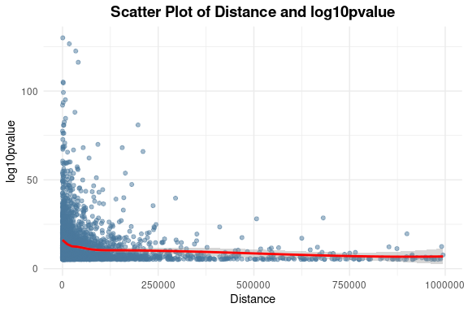

```r
#Scatter Plot of Distance vs. log10pvalue
ggplot(data, aes(x = Distance, y = log10pvalue)) +
  geom_point(alpha = 0.5, color = "#4b789c") +
  geom_smooth(method = "loess", color = "red", linewidth = 1) +  # Smoothed trend line
  theme_minimal() +
  labs(title = "Scatter Plot of Distance and log10pvalue",
       x = "Distance", y = "log10pvalue") +
  theme(plot.title = element_text(hjust = 0.5, face = "bold", size = 14))
```

The scatter plot reveals a clear tendency where higher log10pvalues are concentrated at shorter distances (near 0). This suggests that SNPs located closer to genes tend to have stronger regulatory effects on gene expression, reinforcing the idea that cis-eQTLs (variants acting near their target genes) are more likely to be significant than trans-eQTLs (variants acting at long distances). This finding aligns with known biological mechanisms, as proximal regulatory elements such as promoters and enhancers often have a stronger influence on transcriptional activity than distal elements. However, some significant SNPs at longer distances could indicate the presence of long-range chromatin interactions or trans-regulatory effects. Further analysis could explore whether specific chromosomes or gene types exhibit stronger cis- or trans-regulatory patterns.

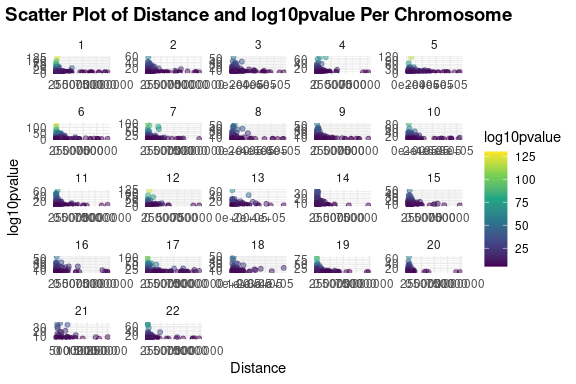

```r
#Scatter Plot of Distance and log10pvalue Per Chromosome
ggplot(data, aes(x = Distance, y = log10pvalue, color = log10pvalue)) +
  geom_point(alpha = 0.5) +
  scale_color_viridis_c() +
  theme_minimal() +
  labs(title = "Scatter Plot of Distance and log10pvalue Per Chromosome",
       x = "Distance", y = "log10pvalue", color = "log10pvalue") +
  facet_wrap(~CHR_SNP, scales = "free") +
  theme(legend.position = "right")+
  theme( plot.title = element_text(hjust = 0.5, face = "bold", size = 14))
```

The following plot shows the relationship between distance and log10(p-value) for SNPs across all chromosomes. A clear trend is observed where higher log10(p-values) are concentrated at lower distances, suggesting that the most significant eQTLs tend to be located closer to the genes they regulate. However, with all chromosomes included, the visualization becomes cluttered, making it difficult to distinguish which chromosomes harbor the most significant regulatory variants. Since the objective is to analyze the most significant SNPs (log10pvalue > 100) and determine whether they are located at the shortest possible distances, we could exclude chromosomes that do not contain such highly significant variants. This approach would allow a clearer and more interpretative visualization, focusing only on regions where the strongest regulatory signals occur.

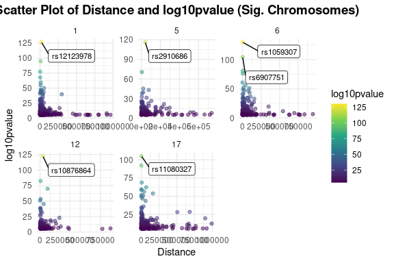

```r
# Scatter plot of significant chromosomes
# Define threshold for significance
threshold <- 100

# Filter chromosomes that contain at least one log10pvalue > 100
significant_chr <- unique(data$CHR_SNP[data$log10pvalue > threshold])

# Subset data to only include those chromosomes
filtered_data <- data[data$CHR_SNP %in% significant_chr, ]

# Subset data for labeling significant SNPs
highlight_snps <- filtered_data[filtered_data$log10pvalue > threshold, ]

# Plot
scatter_plot <- ggplot(filtered_data, aes(x = Distance, y = log10pvalue, color = log10pvalue)) +
  geom_point(alpha = 0.5) +
  scale_color_viridis_c() +
  facet_wrap(~CHR_SNP, scales = "free") +
  geom_label_repel(data = highlight_snps,
                   aes(label = SNP_ID),
                   size = 3, color = "black",
                   force = 1.5,
                   box.padding = 0.5) +
  theme_minimal() +
  labs(title = "Scatter Plot of Distance and log10pvalue (Sig. Chromosomes)",
       x = "Distance", y = "log10pvalue", color = "log10pvalue") +
  theme(legend.position = "right")+
  theme( plot.title = element_text(hjust = 0.5, face = "bold", size = 14))

scatter_plot
```

The refined scatter plot demonstrates that the highest log10pvalues (>100) are found at very short distances, confirming that the most significant regulatory variants are predominantly cis-eQTLs (acting near their target genes). This supports the hypothesis that strong eQTL signals tend to be closer to the regulated genes, emphasizing the importance of proximal regulatory elements such as enhancers and promoters. Chromosomes 1, 5, 6, 12, and 17 contain the most significant SNPs, highlighting potential regulatory hotspots in these regions. These findings align with previous Manhattan plot observations, reinforcing the evidence that eQTL significance is inversely related to distance.

Finally, we can say that the best plots are the Manhattan plot, the heat map plot and the scatter plot of distance and log10p-value of significant chromosomes:

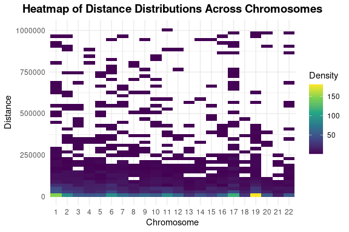

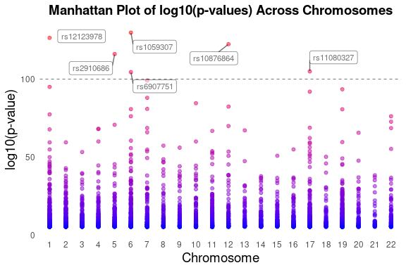

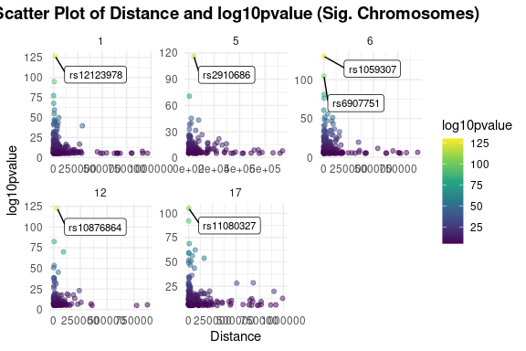